# Replication of Ectoparasite Statistics

Brenna Stallings

12/16/2019

# Paper Overview

This is for the paper titled “Ectoparasites increase swimming costs in a coral reef fish” published in Biology Letters in 2012

## Background

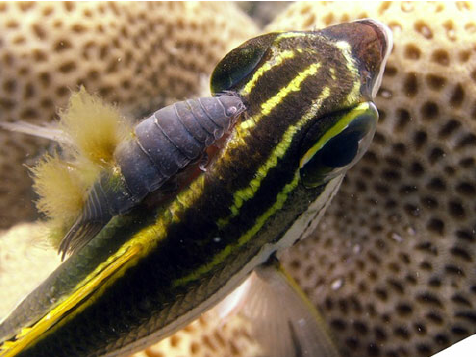

[figure not shown]

Ectoparasites such as isopods can reduce the fitness of the fish they parasitize. However, there is little known about whether the energetic costs are due to changes in the streaming of the fish or by changes in the host’s physiology. This paper used the Bridled Monocle Bream, *Scolopsis bilineatus*, an Indo-Pacific reef fish, and a natural parasite, the *Anilocra nemipteri* isopod to attemot to answer the question. This parasite can be up to 15% of the host’s body length, leading to possible changes to the fish’s streamlining. They wanted to separate out what changes were from each of the two possibilities by testing fish from parasitized and unparasitized groups, as well as groups that had parasites removed, and a group that had fake parasites added.

## Data Used and Analysis

The data for this paper is in the Dryad Repository, found [here](https://datadryad.org/stash/dataset/doi:10.5061/dryad.r73v3). There are two data files. The first has the data for speed and MO2, which is the oxygen consumption rate for the fish. The second file has the data on metabolic rates, critical swimming speed, and aerobic scope. The paper also references data on the size and mass of the fish used and the size of the parasites, but the data isn’t included in the repository. The authors measured the standard and maximum metabolic rates and the critical speed, using it to calculate a oxygen consumption curve and the aerobic scope. They ran one-way ANOVAs to compare Ucrit, SMR, MMR, and AS between treatments. They also used a linear mixed effect model to look at the difference between oxygen consumption rate curves.

## Replication Done

I replicated the mean and se calculations for the variables, all the ANOVAs and PostHoc tests, as well as both Figures 1 and 2. I also replicated the regressions for the MO2 curves.

# Bringing in Data

First we need to call in the data from the original paper. The data is linked to [here](https://datadryad.org/stash/dataset/doi:10.5061/dryad.r73v3) but I downloaded it.

## Bringing into Excel

There are 2 .txt files that I cleaned up in excel to save as .csv. The text file had each line, with all the data for a single fish, enclosed in " ", but I removed them when I opened the file in excel. I separated the variables to different columns. There was no missing data, no 0s or NAs, so I didn’t change any values. I just saved it as a csv.

## Read into R

```r
#This is for all the libraries I will need
library(curl)
library(ggplot2)
library(plyr)
library(dplyr)
library(nlme)
library(agricolae)
library(multcompView)
library(grid)
library(gtable)
library(lsmeans)
```

We are reading the .csv into R and looking at the data

```r
f <- "~/GitHub/Paper Recreation Project/ParasiteData.csv"

d <- read.csv(f, header = TRUE, sep =",", stringsAsFactors = FALSE)
head(d)
```

```
##   ï...fish.treatment.speed.MO2..1 X.fish.treatment.speed.MO2..2
## 1                             P11                          2_UN
## 2                             P21                          2_UN
## 3                             P22                          2_UN
## 4                             P33                          2_UN
## 5                             P31                          2_UN
## 6                             P24                          2_UN
##   X.fish.treatment.speed.MO2..3 X.fish.treatment.speed.MO2..4
## 1                          0.75                     193.03810
## 2                          0.75                     141.94067
## 3                          0.75                     148.06900
## 4                          0.75                      92.37333
## 5                          0.75                     153.23333
## 6                          0.75                      84.58433
```

```r
#it's not right, the column names werent imported correctly, so we fix that...
colnames(d)<- c("Fish ID", "Treatment", "Speed", "MO2")
head(d)
```

```
##   Fish ID Treatment Speed       MO2
## 1     P11      2_UN  0.75 193.03810
## 2     P21      2_UN  0.75 141.94067
## 3     P22      2_UN  0.75 148.06900
## 4     P33      2_UN  0.75  92.37333
## 5     P31      2_UN  0.75 153.23333
## 6     P24      2_UN  0.75  84.58433
```

```r
summary(d)
```

```
##    Fish ID           Treatment             Speed            MO2
##  Length:276         Length:276         Min.   :0.750   Min.   : 68.06
##  Class :character   Class :character   1st Qu.:1.250   1st Qu.:167.69
##  Mode  :character   Mode  :character   Median :2.250   Median :225.03
##                                        Mean   :2.348   Mean   :265.24
##                                        3rd Qu.:3.250   3rd Qu.:323.03
##                                        Max.   :4.750   Max.   :687.87
```

We also need to read in the other file with the values they used for their ANOVA, which I plan on re-doing

```r
e<- "~/GitHub/Paper Recreation Project/ANOVAdata.csv"
g<- read.csv(e, sep=",")
summary(g)
```

```
##     ï..Fish   Treatment      SMR              MMR              AS
##  P10    : 1   FUN:10    Min.   : 57.28   Min.   :358.3   Min.   :2.700
##  P105   : 1   P  :10    1st Qu.: 83.13   1st Qu.:449.2   1st Qu.:4.277
##  P107   : 1   REM:10    Median :102.99   Median :517.0   Median :4.955
##  P108   : 1   UN : 8    Mean   :101.78   Mean   :514.6   Mean   :5.383
##  P109   : 1             3rd Qu.:118.37   3rd Qu.:569.7   3rd Qu.:6.577
##  P11    : 1             Max.   :152.73   Max.   :734.5   Max.   :9.930
##  (Other):32
##      Ucrit
##  Min.   :2.470
##  1st Qu.:3.440
##  Median :3.655
##  Mean   :3.756
##  3rd Qu.:4.005
##  Max.   :4.820
##
```

```r
head(g)
```

```
##   ï..Fish Treatment    SMR    MMR   AS Ucrit
## 1     P10         P 110.20 535.80 4.86  3.79
## 2     P12         P 140.11 471.45 3.36  3.66
## 3     P27         P 135.84 573.08 4.22  2.47
## 4     P42         P 140.44 379.69 2.70  3.65
## 5     P15         P 120.54 561.93 4.66  3.52
## 6     P23         P 108.02 375.57 3.48  3.39
```

- Fish= Fish ID
- Treatment= unparasitized (UN), parasitized (P), parasite removed (REM), parasite added(FUN)
- SMR= standard metabolic rate
- MMR= maximum metabolic rate
- AS= factorial aerobic scope
- Ucrit= critical swimming speed

## Cleaning data

Once I got the data into R, I had to fix a couple of problems. The two tables have different ways of naming the treatments. I am going to fix them so they both sort the same way

```r
#This line gives the new names in relation to the original
treats<- c(P = "1_P", UN= "2_UN", FUN = "3_FUN", REM= "4_REM")
#This fixes the names in the file
g$Treatment <- recode(g$Treatment, !!!treats)

#This line is to be used with the graphs, which are in a different order than the variable names
treat.order<- c("1_P", "2_UN", "4_REM", "3_FUN")
```

# Running Stats

## Checking Normality

First I checked the normality for all the variables, as they are used in ANOVAs, regardless of the fact that the authors do not mention it in the paper.

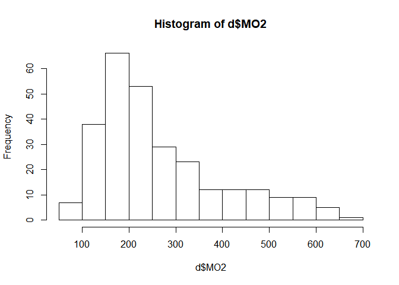

```r
hist(d$MO2)
```

This histogram doesn’t seem very normal.

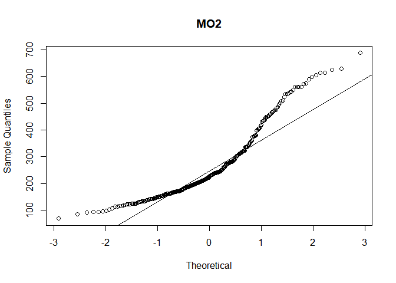

```r
qqnorm(d$MO2, xlab="Theoretical",main="MO2")
qqline(d$MO2)
```

```r
shapiro.test(d$MO2)
```

```
##
##  Shapiro-Wilk normality test
##
## data:  d$MO2
## W = 0.89329, p-value = 4.989e-13
```

This data is clearly not normal, which is good to keep in mind going forward.

These are my tests for normality for data in the second file

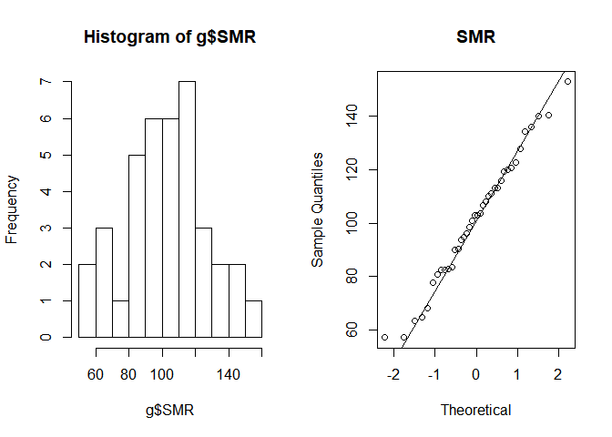

```
##
##  Shapiro-Wilk normality test
##
## data:  g$SMR
## W = 0.98397, p-value = 0.8509
```

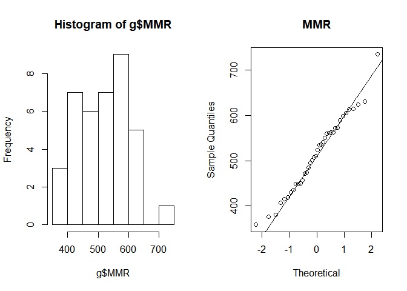

```
##
##  Shapiro-Wilk normality test
##
## data:  g$MMR
## W = 0.97984, p-value = 0.7119
```

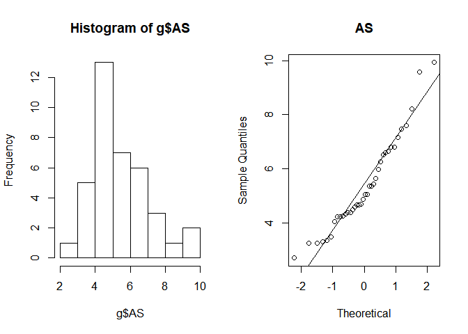

```
##
##  Shapiro-Wilk normality test
##
## data:  g$AS
## W = 0.93808, p-value = 0.03632
```

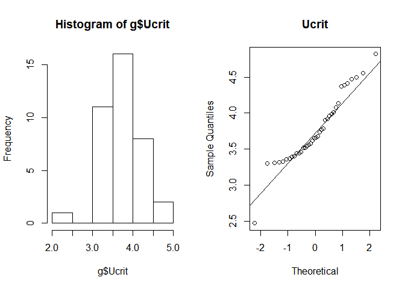

```
##
##  Shapiro-Wilk normality test
##
## data:  g$Ucrit
## W = 0.94242, p-value = 0.0502
```

SMR and MMR look pretty normal. Additionally, both pass the Shapiro test for normality. AS is close to normal until the edges of the qqplot, but doesn’t pass the Shapiro test. Ucrit looks fairly non-normal, but has a p value of about 0.05 in the Shapiro test, so it is walking the edge of normality.

## Means & SE

The paper has descriptive stats for the average size, as length and mass, of the fish as well as stats for the parasites removed from the paper. However, they have no data to go with these analysis in their repository.

There are means for MO2, the ratio of MMR/SMR, and U that are used to create Figure 1. So first I will recreate Figure 1

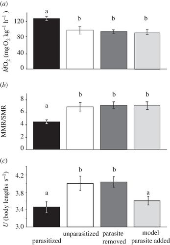

First I need to calculate the mean MO2, MMR/SMR, Ucrit, and the se per treatment. Also, a problem/question: The figure legend says the first graph is SMR, but the graph itself says it is MO2, which are 2 different numbers. hmmm. Seems *fishy*.

### Means for MO2, Fig. 1a

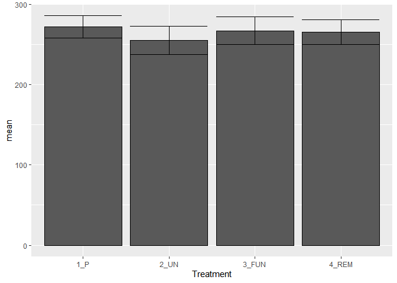

```r
#First we get the mean for each treatment
MO.m<- aggregate(d[,4], list(d$Treatment), mean)
#Then the se for each treatment
se <- function(x) sqrt(var(x)/length(x))
MO.se<- aggregate(d[,4], list(d$Treatment), se)
#make 1 chart to make my life simple
MO<- cbind(MO.m, MO.se[,2])
colnames(MO)<- c("Treatment","mean","SE")
#graph
m<- ggplot(data=MO, aes(Treatment, mean)) + geom_bar(stat="identity", color="black")+ geom_errorbar(aes(ymin=mean-SE, ymax=mean+SE))
m
```

This graph doesn’t match Fig. 1a that is in the paper, the mean is too high. I am going to check the range of numbers for MO2 and see what they look like to check that the coding worked, and the issue is actually the data.

```r
summary(d$MO2)
```

```
##    Min. 1st Qu.  Median    Mean 3rd Qu.    Max.
##   68.06  167.69  225.03  265.24  323.03  687.87
```

So the range of MO2s doesn’t match the range on the graph. The maximum for MO2 is much higher than is on the graph. Even taking the fact that the graph is the means, it seems far to high to be correct.

I’ll try the SMR, which the legend says

```r
#Check the range
summary(g$SMR)
```

```
##    Min. 1st Qu.  Median    Mean 3rd Qu.    Max.
##   57.28   83.13  102.99  101.78  118.37  152.73
```

The ranges seem much more reasonable to go with the graph, so I will try making the graph again.

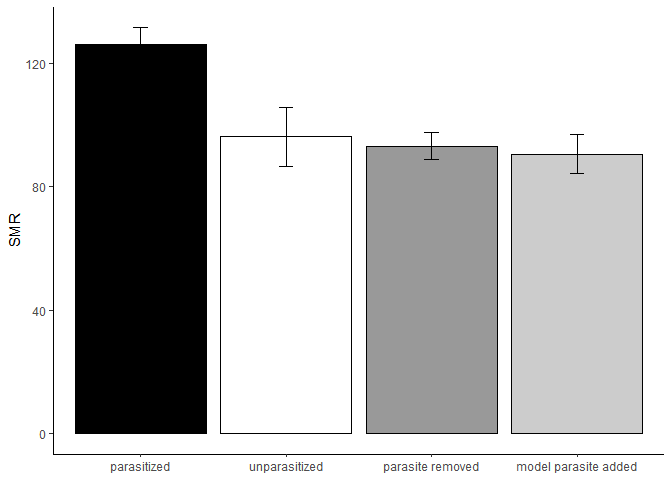

```r
#calculate values
SMR.m<- aggregate(g[,3], list(g$Treatment), mean)
SMR.se<- aggregate(g[,3], list(g$Treatment), se)
SMR<- cbind(SMR.m, SMR.se[,2])
colnames(SMR)<- c("Treatment","mean","SE")

#graph
s<- ggplot(data=SMR, aes(Treatment, mean, y, fill=Treatment)) + geom_bar(stat="identity", color="black")+ geom_errorbar(aes(ymin=mean-SE, ymax=mean+SE), width=.1) + scale_x_discrete(limits=c("1_P", "2_UN", "4_REM", "3_FUN"), labels= c("parasitized", "unparasitized", "parasite removed", "model parasite added")) + scale_y_continuous(breaks=c(0,40,80,120), name = "SMR") + scale_fill_manual(values=c("#cccccc","#000000","#999999","#ffffff"))+theme(legend.position = "none", axis.title.x = element_blank(), panel.grid.major = element_blank(), panel.grid.minor = element_blank(), panel.background = element_blank(), axis.line = element_line(color="black"))
s
```

I will need to calculate significance for adding notation, which I do later. I will also remove the x labels to put parts a-c together.

So Fig. 1a was made with SMR, which agrees with the legend. The Standard Metabolic Weight is related to MO2, as SMR is used as part of the equation to calculate MO2, but they are 2 different values, so the graph should have the y-axis labeled as SMR, which mine has done.

I also noticed that the order they have their treatments labeled is not the order that their graphs are, which is not wrong but is a bit annoying once it is stacking up with everything.

**Hopefully** the other 2 parts of the figure go better…

### Means for MMR/SMR, Fig. 1b

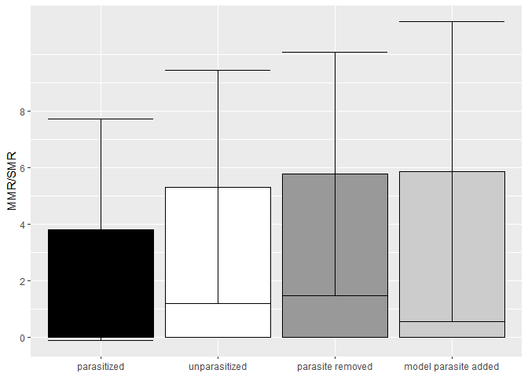

```r
#Calculate
mmr.m<- aggregate(g[,4], list(g$Treatment), mean)
mmr.se<- aggregate(g[,4], list(g$Treatment), se)
mmr<- cbind(mmr.m, mmr.se[,2])
colnames(mmr)<- c("Treatment","mean","SE")
#Get MMR/SMR
#SMR values were calculated above for Fig. 1
m.s.m<-mmr$mean/SMR$mean
#not sure this is how to get the SE
m.s.se<-mmr$SE/SMR$SE
m.s<- cbind(treat.order, m.s.m, m.s.se)
m.s<- as.data.frame(m.s)
colnames(m.s)<- c("Treatment","mean","SE")
m.s$mean<- as.numeric(levels(m.s$mean))
m.s$SE<- as.numeric(levels(m.s$SE))

#Graph
r<- ggplot(data=m.s, aes(Treatment, mean, y, fill=Treatment)) + geom_bar(stat="identity", color="black")+ geom_errorbar(aes(ymin=mean-SE, ymax=mean+SE)) + scale_x_discrete(limits=c("1_P", "2_UN", "4_REM", "3_FUN"), labels= c("parasitized", "unparasitized", "parasite removed", "model parasite added")) + scale_y_continuous(breaks=c(0,2,4,6,8), name = "MMR/SMR") + scale_fill_manual(values=c("#000000","#ffffff","#cccccc","#999999"))+theme(legend.position = "none", axis.title.x = element_blank())
r
```

So the error bars are clearly wrong. However, more importantly, the bars are not the same relative heights as they are in the paper. In the paper, REM appears slightly higher than UN and FUN, while in mine, FUN is the tallest, then REM, then UN. I’m going to ignore the error bars as they are currently a minor problem.

I wonder if the reason that my numbers are off is because I aggregated the data and then found the ratio. Next I tried using their AS value, which is the ratio of MMR to SMR. That way, it takes my issue off the table, since the ratio is calculated first.

```r
#This is with the data they calculated as AS
as.m<- aggregate(g[,5], list(g$Treatment), mean)
as.se<- aggregate(g[,5], list(g$Treatment), se)
as<- cbind(as.m, as.se[,2])
colnames(as)<- c("Treatment","mean","SE")
as
```

```
##   Treatment    mean        SE
## 1     3_FUN 6.19100 0.6152135
## 2       1_P 3.85100 0.2317683
## 3     4_REM 5.89700 0.3806954
## 4      2_UN 5.64625 0.6523144
```

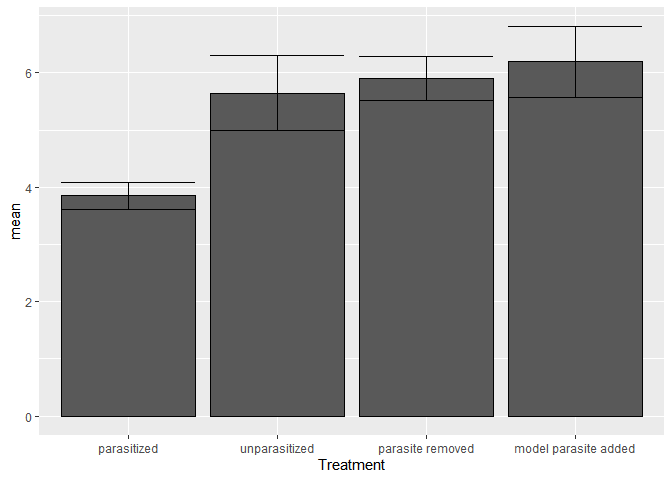

```r
#Graph
a<- ggplot(data=as, aes(Treatment, mean, y ))  + geom_bar(stat="identity", color="black")+ geom_errorbar(aes(ymin=mean-SE, ymax=mean+SE)) + scale_x_discrete(limits=c("1_P", "2_UN", "4_REM", "3_FUN"), labels= c("parasitized", "unparasitized", "parasite removed", "model parasite added"))
a
```

This looks closer but the last two columns seem switched, as the graph in the paper looks like the Parasite Removed has the highest bar.

```r
as
```

```
##   Treatment    mean        SE
## 1     3_FUN 6.19100 0.6152135
## 2       1_P 3.85100 0.2317683
## 3     4_REM 5.89700 0.3806954
## 4      2_UN 5.64625 0.6523144
```

This way has treatment 3, FUN, with the highest AS, at 6, but their graph looks like treatment 4, REM, is slightly higher. And treatments 2-4 look like they are all above 6 in their graph.

So far I have tried 2 ways to get their AS numbers for Fig.1b: I have found the average MMR and SMR and dividing them out and I have divided MMR by SMR individually and then averaged(this one technically they did).

I’m going to try to calculate AS myself for each fish then average across treatments

```r
AS.Brenna<- cbind(g[,2], g[,4], g[,3])
colnames(AS.Brenna)<- c("Treatment", "MMR", "SMR")
#The treatments are getting put in worng. I need to switch them
#treats   <- c(P = "1_P", UN= "2_UN", FUN = "3_FUN", REM= "4_REM")
treats.2 <- c("1" = "3_FUN", "2"= "1_P", "3"= "4_REM", "4"= "2_UN")
AS.Brenna[,1] <- recode(AS.Brenna[,1], !!!treats.2)
AS.Brenna<- as.data.frame(AS.Brenna)
AS.Brenna$MMR<- as.numeric(as.character(AS.Brenna$MMR))
AS.Brenna$SMR<- as.numeric(as.character(AS.Brenna$SMR))
#AS.Brenna$MMR<- droplevels(AS.Brenna$MMR)
#AS.Brenna$CalculatedAS = NA
#calc.AS<- AS.Brenna$MMR / AS.Brenna$SMR
AS.Brenna<- mutate(AS.Brenna, CalculatedAS=MMR/SMR)
AS.Brenna$CalculatedAS<- round(AS.Brenna$CalculatedAS, digits = 2)
match(AS.Brenna$CalculatedAS, g$AS)
```

```
##  [1]  1  2  3  4  5  6  7  8  9  8 11 12 13 14 15 NA 17 18 19  5 21 22 23
## [24] 24 25 26 27 27 29 30 31 32 33 34 35 36 37 38
```

There are 4 values that dont match, the 10th, 16th, 20th, and the 28th

```r
my.calc<-c(AS.Brenna[10,4],AS.Brenna[16,4],AS.Brenna[20,4],AS.Brenna[28,4])
their.calc<-c(g[10,5], g[16,5],  g[20,5], g[28,5])
              rbind(my.calc, their.calc)
```

```
##            [,1] [,2] [,3] [,4]
## my.calc    3.24 6.25 4.66 6.79
## their.calc 3.24 6.26 4.66 6.79
```

It just looks like rounding for all of these, so the math checks out, which means that this should be exactly the same

```r
aggregate(AS.Brenna[,4], list(AS.Brenna$Treatment), mean)
```

```
##   Group.1     x
## 1     1_P 3.851
## 2    2_UN 5.645
## 3   3_FUN 6.191
## 4   4_REM 5.897
```

```r
as
```

```
##   Treatment    mean        SE
## 1     3_FUN 6.19100 0.6152135
## 2       1_P 3.85100 0.2317683
## 3     4_REM 5.89700 0.3806954
## 4      2_UN 5.64625 0.6523144
```

And they match. So their calculations for AS are right. Since all the calculations are correct, the most likely explanation is that they took out outlier points, and didn’t mention them in the paper. So the graph that I am going with is with their calculated AS values, since it seems like all the math adds up.

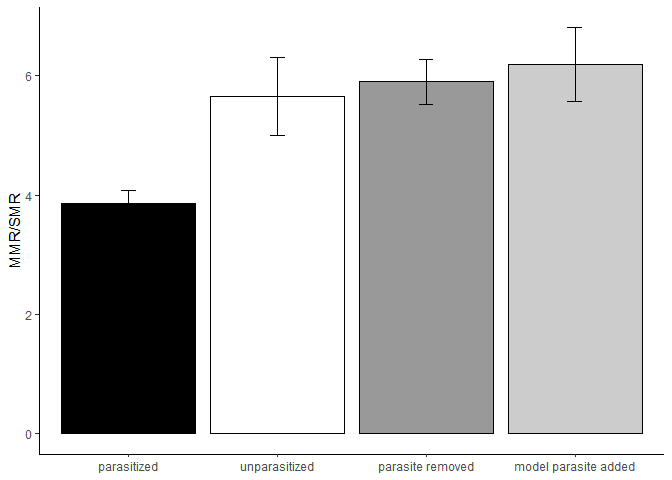

```r
a<- ggplot(data=as, aes(Treatment, mean, y, fill=Treatment)) + geom_bar(stat="identity", color="black")+ geom_errorbar(aes(ymin=mean-SE, ymax=mean+SE), width=.1) + scale_x_discrete(limits=c("1_P", "2_UN", "4_REM", "3_FUN"), labels= c("parasitized", "unparasitized", "parasite removed", "model parasite added")) + scale_y_continuous(breaks=c(0,2,4,6,8), name = "MMR/SMR") + scale_fill_manual(values=c("#cccccc","#000000","#999999","#ffffff"))+theme(legend.position = "none", axis.title.x = element_blank(), panel.grid.major = element_blank(), panel.grid.minor = element_blank(), panel.background = element_blank(), axis.line = element_line(color="black"))
a
```

### Means for U, Fig. 1c

```r
#Calculation
u.m<- aggregate(g[,6], list(g$Treatment), mean)
u.se<- aggregate(g[,6], list(g$Treatment), se)
u<- cbind(u.m, u.se[,2])
colnames(u)<- c("Treatment","mean","SE")
#this changes the names of the treatments
u$Treatment<- c("model parasite added","parasitized",  "parasite removed", "unparasitized")
#this changes the levels for the treatments
levels(u$Treatment) <-c("parasitized", "unparasitized", "model parasite added", "parasite removed")
u
```

```
##              Treatment    mean         SE
## 1 model parasite added 3.60500 0.09679589
## 2          parasitized 3.46300 0.12103305
## 3     parasite removed 4.03900 0.12081621
## 4        unparasitized 3.95875 0.20605510
```

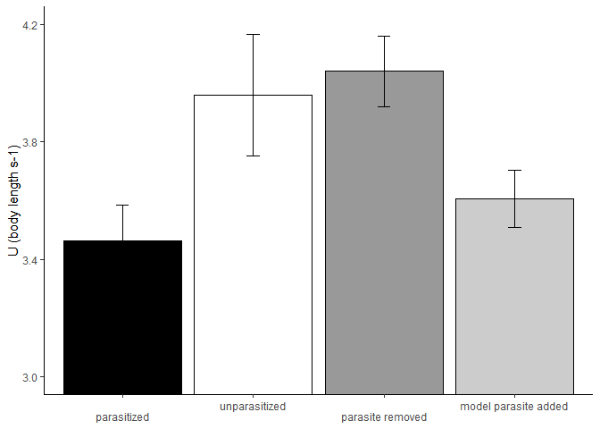

```r
#Graph
c<- ggplot(data=u, aes(Treatment, mean, y, fill=Treatment )) + geom_bar(stat="identity", color="black") +geom_errorbar(aes(ymin=mean-SE, ymax=mean+SE), width=.1) +
scale_fill_manual(values=c("#cccccc","#999999","#000000", "#ffffff")) + scale_y_continuous(name = "U (body length s-1)",breaks=c(3,3.4,3.8,4.2))+ coord_cartesian(ylim=c(3,4.2))+theme(legend.position = "none", axis.title.x = element_blank(), panel.grid.major = element_blank(), panel.grid.minor = element_blank(), panel.background = element_blank(), axis.line = element_line(color="black"))+scale_x_discrete(limits= c("parasitized", "unparasitized", "parasite removed", "model parasite added"),labels=function(labels) {
    sapply(seq_along(labels), function(i) paste0(ifelse(i %% 2 == 0, '', '\n'), labels[i]))
  })
c
```

This graph seems to match the paper pretty well. The numbers and order match up.

## Figure 1

I am going to make 1 graph.

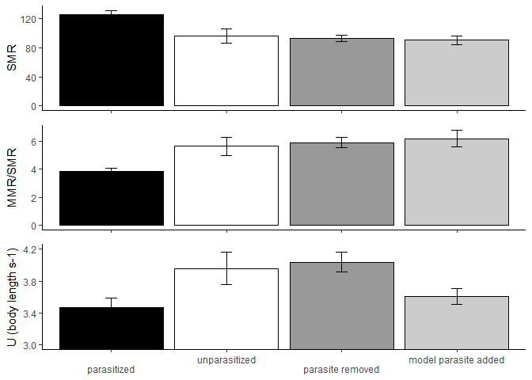

```r
#This is to remove the x axis labels from the first 2 graphs
s<- s+theme(legend.position = "none", axis.title.x = element_blank(),axis.text.x = element_blank())
a<- a+theme(legend.position = "none", axis.title.x = element_blank(),axis.text.x = element_blank())


#then I need to convert the graphs to Grobs
s2<- ggplotGrob(s)
a2<- ggplotGrob(a)
c2<- ggplotGrob(c)
#then we set the sizes to be the same
b <-rbind(s2,a2,c2, size="first")
grid.newpage()
grid.draw(b)
```

And this is the original I was recreating next to it

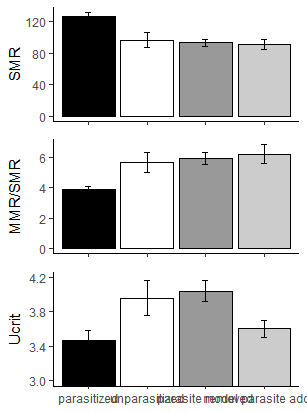

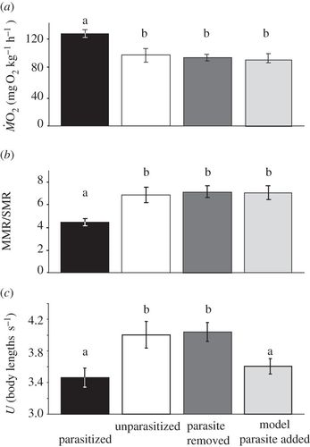

## ANOVAs

They used 1-way ANOVA and a Tukey HSD post hoc test to examine the difference between Ucrit, SMR, MMR, and AS between treatments. They log transformed AS.

All ANOVAs work with factors, so I want to make sure that Treatment is a factor

```r
str(g$Treatment)
```

```
##  Factor w/ 4 levels "3_FUN","1_P",..: 2 2 2 2 2 2 2 2 2 2 ...
```

```r
summary(g$Treatment)
```

```
## 3_FUN   1_P 4_REM  2_UN
##    10    10    10     8
```

### Ucrit ANOVA

First I will look at the data to see if I can visually spot a trend

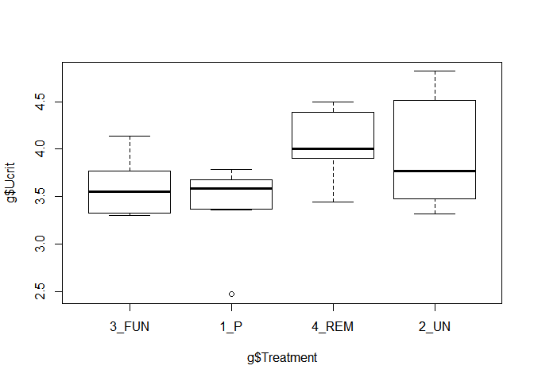

```r
plot(g$Ucrit~ g$Treatment)
```

It looks like the Removed and possible the Unparasitized groups may be higher than the other 2.

For the ANOVA

```r
#First I am going to reorder the factors
g$Treatment <- factor(g$Treatment, levels = c("1_P", "2_UN", "3_FUN", "4_REM"))

#Then I run the test
U.an<- aov(data=g, g$Ucrit~ g$Treatment)
summary(U.an)
```

```
##             Df Sum Sq Mean Sq F value Pr(>F)
## g$Treatment  3  2.216  0.7387   4.291 0.0113 *
## Residuals   34  5.853  0.1721
## ---
## Signif. codes:  0 '***' 0.001 '**' 0.01 '*' 0.05 '.' 0.1 ' ' 1
```

```r
#Then the Post-Hoc, 2 ways
post.u<- TukeyHSD(U.an)
post.u
```

```
##   Tukey multiple comparisons of means
##     95% family-wise confidence level
##
## Fit: aov(formula = g$Ucrit ~ g$Treatment, data = g)
##
## $`g$Treatment`
##                 diff         lwr       upr     p adj
## 2_UN-1_P     0.49575 -0.03578919 1.0272892 0.0748188
## 3_FUN-1_P    0.14200 -0.35913995 0.6431400 0.8694505
## 4_REM-1_P    0.57600  0.07486005 1.0771400 0.0191043
## 3_FUN-2_UN  -0.35375 -0.88528919 0.1777892 0.2921030
## 4_REM-2_UN   0.08025 -0.45128919 0.6117892 0.9767341
## 4_REM-3_FUN  0.43400 -0.06713995 0.9351400 0.1091184
```

```r
post.u2<- HSD.test(U.an, "g$Treatment", console = T)
```

```
##
## Study: U.an ~ "g$Treatment"
##
## HSD Test for g$Ucrit
##
## Mean Square Error:  0.1721482
##
## g$Treatment,  means
##
##       g.Ucrit       std  r  Min  Max
## 1_P   3.46300 0.3827401 10 2.47 3.79
## 2_UN  3.95875 0.5828118  8 3.32 4.82
## 3_FUN 3.60500 0.3060955 10 3.30 4.14
## 4_REM 4.03900 0.3820544 10 3.44 4.50
##
## Alpha: 0.05 ; DF Error: 34
## Critical Value of Studentized Range: 3.819512
##
## Groups according to probability of means differences and alpha level( 0.05 )
##
## Treatments with the same letter are not significantly different.
##
##       g$Ucrit groups
## 4_REM 4.03900      a
## 2_UN  3.95875     ab
## 3_FUN 3.60500     ab
## 1_P   3.46300      b
```

The second test gives the letters of groups that are statistically similar. It has the same finding as the first, that only REM and P are different. This is not the letter scheme that the graph had, so that was incorrect. Their graph has P and FUN in a group that is significantly different than REM and UN as a group.

### SMR ANOVA

First I will visualize the data

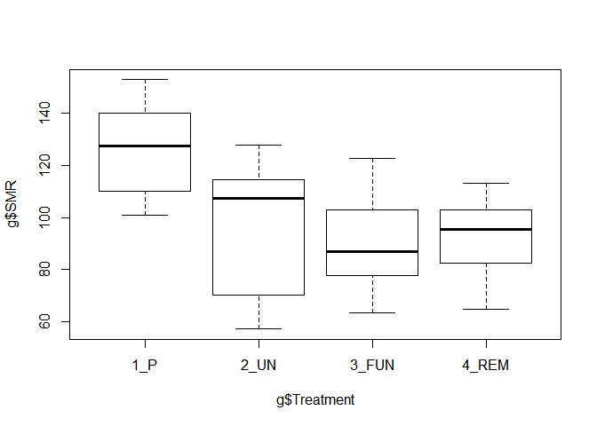

The Parasitized group looks like it will be different, and maybe the unparasitized group as well. Then I’ll run the test.

```
##             Df Sum Sq Mean Sq F value   Pr(>F)
## g$Treatment  3   8237  2745.6   7.152 0.000753 ***
## Residuals   34  13052   383.9
## ---
## Signif. codes:  0 '***' 0.001 '**' 0.01 '*' 0.05 '.' 0.1 ' ' 1
```

They reported that P had a higher SMR than the other 3 treatments with a value of F 3,34=7.152, p<0.001. The p value and the F value both match with the paper.

Then I check the Post Hocs

```
##   Tukey multiple comparisons of means
##     95% family-wise confidence level
##
## Fit: aov(formula = g$SMR ~ g$Treatment, data = g)
##
## $`g$Treatment`
##                  diff       lwr        upr     p adj
## 2_UN-1_P    -30.05225 -55.15235  -4.952146 0.0137920
## 3_FUN-1_P   -35.68300 -59.34760 -12.018395 0.0014360
## 4_REM-1_P   -33.08600 -56.75060  -9.421395 0.0032754
## 3_FUN-2_UN   -5.63075 -30.73085  19.469354 0.9295077
## 4_REM-2_UN   -3.03375 -28.13385  22.066354 0.9877729
## 4_REM-3_FUN   2.59700 -21.06760  26.261605 0.9907784
```

The Post Hoc test show the largest difference between Parasitized and everything else. The other 3 groups are all very similar to each other, which matches the paper.

```
##
## Study: smr.an ~ "g$Treatment"
##
## HSD Test for g$SMR
##
## Mean Square Error:  383.8688
##
## g$Treatment,  means
##
##           g.SMR      std  r    Min    Max
## 1_P   126.20600 16.88040 10 100.86 152.73
## 2_UN   96.15375 27.09763  8  57.28 127.75
## 3_FUN  90.52300 19.91124 10  63.43 122.66
## 4_REM  93.12000 14.05908 10  64.92 112.96
##
## Alpha: 0.05 ; DF Error: 34
## Critical Value of Studentized Range: 3.819512
##
## Groups according to probability of means differences and alpha level( 0.05 )
##
## Treatments with the same letter are not significantly different.
##
##           g$SMR groups
## 1_P   126.20600      a
## 2_UN   96.15375      b
## 4_REM  93.12000      b
## 3_FUN  90.52300      b
```

The second Post Hoc test gives the letter groups as P being one group and everything else as a second group, which matches the paper.

### MMR ANOVA

First I will visualize the data

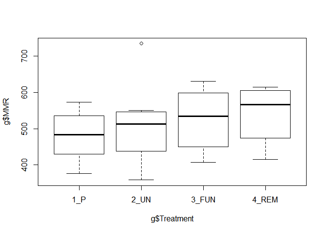

They all look relatively similar. FUN and REM are slightly higher, but I doubt it is significant.

Then run the test

```
##             Df Sum Sq Mean Sq F value Pr(>F)
## g$Treatment  3  20336    6779   0.963  0.421
## Residuals   34 239388    7041
```

The paper reported no difference between groups, with a statistic of F 3, 34= 0.992, p=0.408. There is no significant difference between groups, which matches the paper. My numbers are slightly different, however. My stat is F 3, 34= 0.963, p= 0.421. So while neither number matches exactly, they both come to the same conclusion.

```
##   Tukey multiple comparisons of means
##     95% family-wise confidence level
##
## Fit: aov(formula = g$MMR ~ g$Treatment, data = g)
##
## $`g$Treatment`
##                 diff       lwr      upr     p adj
## 2_UN-1_P    31.66375 -75.83319 139.1607 0.8559604
## 3_FUN-1_P   50.57300 -50.77608 151.9221 0.5398982
## 4_REM-1_P   58.61800 -42.73108 159.9671 0.4131670
## 3_FUN-2_UN  18.90925 -88.58769 126.4062 0.9640644
## 4_REM-2_UN  26.95425 -80.54269 134.4512 0.9050073
## 4_REM-3_FUN  8.04500 -93.30408 109.3941 0.9964504
```

The post hoc test shows that nothing is even close to significance, which the paper agrees with. They do not report a value for the Tukey, presumably because there was no difference.

### AS ANOVA- log transformed

First I will visualize the data, which was log10 transformed.

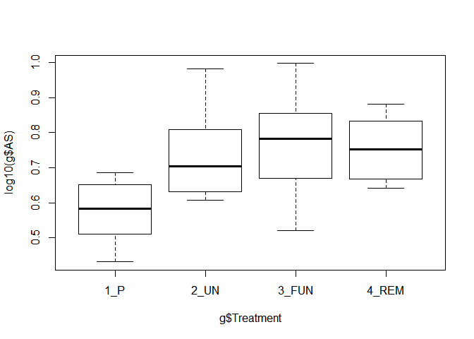

```r
plot(log10(g$AS)~ g$Treatment)
```

The Parasitized group looks like it will be lower than the other three treatment. Then I run the tests.

```r
as.an<- aov(data=g, log10(g$AS)~ g$Treatment)
summary(as.an)
```

```
##             Df Sum Sq Mean Sq F value Pr(>F)
## g$Treatment  3 0.2444 0.08147   6.543 0.0013 **
## Residuals   34 0.4233 0.01245
## ---
## Signif. codes:  0 '***' 0.001 '**' 0.01 '*' 0.05 '.' 0.1 ' ' 1
```

The first Tukey test

```
##   Tukey multiple comparisons of means
##     95% family-wise confidence level
##
## Fit: aov(formula = log10(g$AS) ~ g$Treatment, data = g)
##
## $`g$Treatment`
##                     diff         lwr       upr     p adj
## 2_UN-1_P     0.156215448  0.01326646 0.2991644 0.0277824
## 3_FUN-1_P    0.193844781  0.05907118 0.3286184 0.0024284
## 4_REM-1_P    0.184177666  0.04940407 0.3189513 0.0041330
## 3_FUN-2_UN   0.037629333 -0.10531965 0.1805783 0.8920610
## 4_REM-2_UN   0.027962218 -0.11498677 0.1709112 0.9516198
## 4_REM-3_FUN -0.009667115 -0.14444071 0.1251065 0.9973720
```

```
##
## Study: as.an ~ "g$Treatment"
##
## HSD Test for log10(g$AS)
##
## Mean Square Error:  0.01245071
##
## g$Treatment,  means
##
##       log10.g.AS.        std  r       Min       Max
## 1_P     0.5782363 0.08495925 10 0.4313638 0.6866363
## 2_UN    0.7344517 0.12629089  8 0.6063814 0.9818186
## 3_FUN   0.7720811 0.13944928 10 0.5198280 0.9969492
## 4_REM   0.7624140 0.08925661 10 0.6414741 0.8802418
##
## Alpha: 0.05 ; DF Error: 34
## Critical Value of Studentized Range: 3.819512
##
## Groups according to probability of means differences and alpha level( 0.05 )
##
## Treatments with the same letter are not significantly different.
##
##       log10(g$AS) groups
## 3_FUN   0.7720811      a
## 4_REM   0.7624140      a
## 2_UN    0.7344517      a
## 1_P     0.5782363      b
```

## Figure 2

For Fig 2, I am starting with the base of the plot, which is the mean and SE of the logMO2 for each treatment at each speed.

Plotting the start of Fig 2

```r
#for each treatment, each x value has a point with error bars and a regression line

#want to get the mean for each treatment at each speed
f2.mean<-aggregate(log(d$MO2), list(d$Treatment, d$Speed), mean)
#the se for each treatment at each speed
f2.se<-aggregate(log(d$MO2), list(d$Treatment, d$Speed), se)
#then put in one table
f2<- cbind(f2.mean, f2.se[,3])
colnames(f2)<- c("Treatment","Speed","mean", "SE")
head(f2)
```

```
##   Treatment Speed     mean         SE
## 1       1_P  0.75 5.015903 0.04668158
## 2      2_UN  0.75 4.886995 0.10323607
## 3     3_FUN  0.75 4.870491 0.05886021
## 4     4_REM  0.75 4.786114 0.06827785
## 5       1_P  1.25 5.207038 0.02897772
## 6      2_UN  1.25 4.954103 0.10526209
```

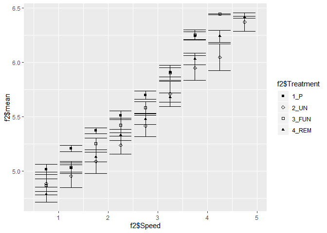

```r
j2<- ggplot(data=f2,aes(x=f2$Speed, y=f2$mean))+ geom_point(aes(shape = f2$Treatment))+ geom_errorbar(aes(ymin=mean-SE, ymax=mean+SE)) + scale_shape_manual(values=c(15, 5, 0, 17))
j2
```

The numbers of the y scale on my graph do not match those of the paper’s. My numbers are much higher than those of the paper. I logged each value before I took the mean, so that should not be the problem. I am going to check the range of values of log(MO2) to see if I am doing something wrong with my graph or there is something wrong with the data again.

```r
summary(log(d$MO2))
```

```
##    Min. 1st Qu.  Median    Mean 3rd Qu.    Max.
##   4.220   5.122   5.416   5.466   5.778   6.534
```

There is something weird about Fig 2. In theory, the y axis is log(MO2), but if you look at the values for the log of MO2, they are between 4 and 6.5, while the graph is from 2 to 3.

Since in Fig 1 they said MO2 but meant SMR, I will check the values for that

```r
summary(log(g$SMR))
```

```
##    Min. 1st Qu.  Median    Mean 3rd Qu.    Max.
##   4.048   4.420   4.635   4.594   4.774   5.029
```

So nope for that as well. Ill try the other variables just in case.

```r
summary(log(g$MMR))
```

```
##    Min. 1st Qu.  Median    Mean 3rd Qu.    Max.
##   5.881   6.108   6.248   6.230   6.345   6.599
```

```r
summary(log(g$AS))
```

```
##    Min. 1st Qu.  Median    Mean 3rd Qu.    Max.
##  0.9933  1.4533  1.6002  1.6362  1.8836  2.2956
```

Neither of these has the right range either.

I also checked log10MO2 which is the stats default but not the r default for log

```r
summary(log10(d$MO2))
```

```
##    Min. 1st Qu.  Median    Mean 3rd Qu.    Max.
##   1.833   2.225   2.352   2.374   2.509   2.838
```

This looks pretty right. It has the right values.

```r
f2.mean<-aggregate(log10(d$MO2), list(d$Treatment, d$Speed), mean)
#the se for each treatment at each speed
f2.se<-aggregate(log10(d$MO2), list(d$Treatment, d$Speed), se)
#then put in one table
f2<- cbind(f2.mean, f2.se[,3])
colnames(f2)<- c("Treatment","Speed","mean", "SE")
head(f2)
```

```
##   Treatment Speed     mean         SE
## 1       1_P  0.75 2.178379 0.02027355
## 2      2_UN  0.75 2.122395 0.04483486
## 3     3_FUN  0.75 2.115227 0.02556267
## 4     4_REM  0.75 2.078583 0.02965269
## 5       1_P  1.25 2.261388 0.01258487
## 6      2_UN  1.25 2.151539 0.04571475
```

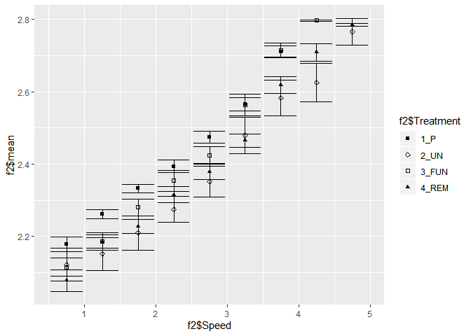

```r
j2<- ggplot(data=f2,aes(x=f2$Speed, y=f2$mean))+ geom_point(aes(shape = f2$Treatment))+ geom_errorbar(aes(ymin=mean-SE, ymax=mean+SE)) + scale_shape_manual(values=c(15, 5, 0, 17))
j2
```

These values look correct for the figure.

## Linear Mixed Effect Model for O2 consumption rate between U and logMO2

The authors used a LMM, which assumes that the data is normally distributed. However, I found earlier that MO2 isn’t normal. However, they use log(MO2), which they may have transformed to be normal

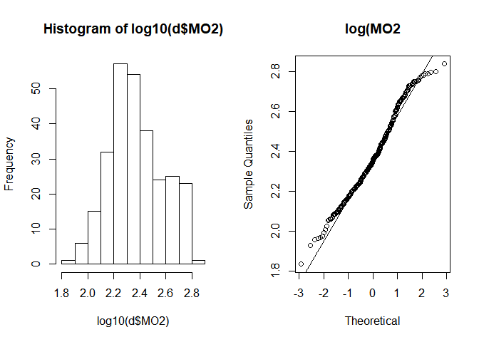

```r
par(mfrow=c(1,2))
hist(log10(d$MO2))
qqnorm(log10(d$MO2), xlab="Theoretical",main="log(MO2")
qqline(log10(d$MO2))
```

```r
shapiro.test(log10(d$MO2))
```

```
##
##  Shapiro-Wilk normality test
##
## data:  log10(d$MO2)
## W = 0.98182, p-value = 0.001383
```

The paper says that they used the lme function to compare the linear oxygen consumption curves as speed increased between treatments. So I am going to run that.

```r
wut<-lme(data=d, log10(MO2) ~ Speed * Treatment, random=~Speed|Treatment)
summary(wut)
```

```
## Linear mixed-effects model fit by REML
##  Data: d
##         AIC       BIC   logLik
##   -507.5683 -464.4765 265.7842
##
## Random effects:
##  Formula: ~Speed | Treatment
##  Structure: General positive-definite, Log-Cholesky parametrization
##             StdDev     Corr
## (Intercept) 0.02702183 (Intr)
## Speed       0.01043366 0
## Residual    0.08417256
##
## Fixed effects: log10(MO2) ~ Speed * Treatment
##                           Value  Std.Error  DF  t-value p-value
## (Intercept)           2.0444406 0.03709167 268 55.11859  0.0000
## Speed                 0.1646564 0.01495062 268 11.01335  0.0000
## Treatment2_UN        -0.0939916 0.05224118   0 -1.79919     NaN
## Treatment3_FUN       -0.0991512 0.05204661   0 -1.90505     NaN
## Treatment4_REM       -0.1086331 0.05109315   0 -2.12618     NaN
## Speed:Treatment2_UN  -0.0039494 0.02038148 268 -0.19378  0.8465
## Speed:Treatment3_FUN  0.0267765 0.02078043 268  1.28854  0.1987
## Speed:Treatment4_REM  0.0097812 0.01998164 268  0.48951  0.6249
##  Correlation:
##                      (Intr) Speed  Tr2_UN T3_FUN T4_REM S:T2_U S:T3_F
## Speed                -0.448
## Treatment2_UN        -0.710  0.318
## Treatment3_FUN       -0.713  0.319  0.506
## Treatment4_REM       -0.726  0.325  0.515  0.517
## Speed:Treatment2_UN   0.329 -0.734 -0.426 -0.234 -0.239
## Speed:Treatment3_FUN  0.322 -0.719 -0.229 -0.436 -0.234  0.528
## Speed:Treatment4_REM  0.335 -0.748 -0.238 -0.239 -0.406  0.549  0.538
##
## Standardized Within-Group Residuals:
##         Min          Q1         Med          Q3         Max
## -3.43765337 -0.62888403  0.06536819  0.71018792  2.55028244
##
## Number of Observations: 276
## Number of Groups: 4
```

```r
anova(wut)
```

```
##                 numDF denDF   F-value p-value
## (Intercept)         1   268 16804.501  <.0001
## Speed               1   268   604.724  <.0001
## Treatment           3     0     1.942     NaN
## Speed:Treatment     3   268     0.914  0.4348
```

```r
lst1<- lstrends(wut, "Treatment", var="Speed")
lst1
```

```
##  Treatment Speed.trend     SE  df lower.CL upper.CL
##  1_P             0.165 0.0150 268    0.135    0.194
##  2_UN            0.161 0.0139 268    0.133    0.188
##  3_FUN           0.191 0.0144 268    0.163    0.220
##  4_REM           0.174 0.0133 268    0.148    0.201
##
## Degrees-of-freedom method: containment
## Confidence level used: 0.95
```

```r
pairs(lst1)
```

```
##  contrast      estimate     SE  df t.ratio p.value
##  1_P - 2_UN     0.00395 0.0204 268  0.194  0.9974
##  1_P - 3_FUN   -0.02678 0.0208 268 -1.289  0.5710
##  1_P - 4_REM   -0.00978 0.0200 268 -0.490  0.9614
##  2_UN - 3_FUN  -0.03073 0.0200 268 -1.536  0.4175
##  2_UN - 4_REM  -0.01373 0.0192 268 -0.716  0.8906
##  3_FUN - 4_REM  0.01700 0.0196 268  0.867  0.8218
##
## Degrees-of-freedom method: containment
## P value adjustment: tukey method for comparing a family of 4 estimates
```

Comparing the slopes, there is a not statistical difference in intercept and speed between groups with adjusted p values. Using linear regressions to compare the relationship between speed and log(MO2) for each treatment. I didn’t find a significant interaction in the relationship for any treatment, P(B=0.165), UN(B=0.161), FUN(B=0.191),REM(B=0.174); F(3,268)= 0.914, p=0.434. This is very different than the paper, which said that the P treatment had a statistically higher intercept than the other treatments, and that the FUN group had a statistically higher slope. I did notice that their stats are reported with 234 df, when there are 276 data points, so there should be 275 df. That probably means they took out data points before their analysis, which would help explain why Fig1.b had different means than what I calculated.

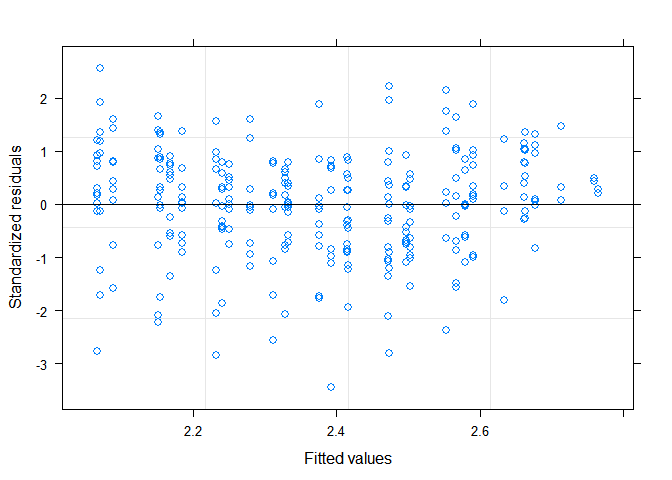

```r
plot(wut)
```

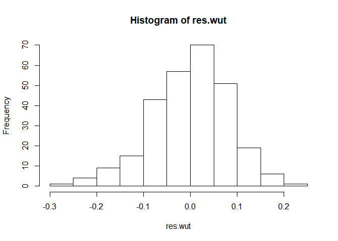

```r
res.wut<-resid(wut)
hist(res.wut)
```

The residuals look OK, not great but maybe acceptable.

I am going to run a sepearate regression for each treatment, to look at the intercepts and slopes individually.

```r
by_treat<- group_by(d, Treatment)
d.1<- d[order(d$Treatment),]
#For 1_P
lm<-lme(log10(MO2) ~ Speed, data=d.1[1:66,],random=~Speed|Treatment)
summary(lm)
```

```
## Linear mixed-effects model fit by REML
##  Data: d.1[1:66, ]
##        AIC       BIC   logLik
##   -174.334 -161.3807 93.16699
##
## Random effects:
##  Formula: ~Speed | Treatment
##  Structure: General positive-definite, Log-Cholesky parametrization
##             StdDev      Corr
## (Intercept) 0.017359429 (Intr)
## Speed       0.007315684 0
## Residual    0.052885751
##
## Fixed effects: log10(MO2) ~ Speed
##                 Value   Std.Error DF  t-value p-value
## (Intercept) 2.0444406 0.023584184 64 86.68693       0
## Speed       0.1646564 0.009938947 64 16.56678       0
##  Correlation:
##       (Intr)
## Speed -0.418
##
## Standardized Within-Group Residuals:
##         Min          Q1         Med          Q3         Max
## -2.16203917 -0.91234542 -0.01977574  0.81411976  1.82121252
##
## Number of Observations: 66
## Number of Groups: 1
```

```r
lm.1<- lm(log10(MO2) ~ Speed, data=d.1[1:66,])
summary(lm.1)
```

```
##
## Call:
## lm(formula = log10(MO2) ~ Speed, data = d.1[1:66, ])
##
## Residuals:
##       Min        1Q    Median        3Q       Max
## -0.114341 -0.048250 -0.001046  0.043055  0.096316
##
## Coefficients:
##             Estimate Std. Error t value Pr(>|t|)
## (Intercept) 2.044441   0.015964  128.06   <2e-16 ***
## Speed       0.164656   0.006728   24.47   <2e-16 ***
## ---
## Signif. codes:  0 '***' 0.001 '**' 0.01 '*' 0.05 '.' 0.1 ' ' 1
##
## Residual standard error: 0.05289 on 64 degrees of freedom
## Multiple R-squared:  0.9035, Adjusted R-squared:  0.902
## F-statistic:   599 on 1 and 64 DF,  p-value: < 2.2e-16
```

The lm test found a regression of 2.044+0.165U with an adjusted R2 of 0.902. This is the same as the paper.

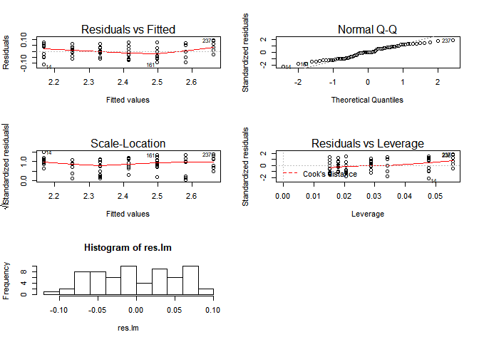

```r
par(mfrow = c(3, 2))
plot(lm.1)

res.lm<-resid(lm.1)
hist(res.lm)
```

The residuals don’t look very normal.